# Weather Forecast Shiny application

Developing Data Products

Sk Minhazul Islam

## Overview

Importance of Weather Foecasting:

1. Weather forecasts and warnings are the most important services provided by the meteorological profession.
2. Forecasts are used by government and industry to protect life and property and to improve the efficiency of operations.
3. Forecasts are usedby individuals to plan a wide range of daily activities.
4. The numerical prediction models have proved successful in 1 to 5 day prediction, cutting edge research make it possible to predict weather for periods beyond 10 to 14 days.
5. Forecast methods and tools for monthly outlooks have been a mixture of dynamical and statistical techniques.
6. The crucial components for weather forecasting are sky condition, temperature, humidity, wind statistics.

— .class #id

## Weather Forecast applicatons

There are a lots of weather forecast application available in different domain:

### Webapplication:

http://www.weather.com/newscenter/nationalforecast/

In the tab “Check local weather:” put the zip code or city name and it will give you the current weather and dependable forecast.

### Smart-phone application:

http://www.weather.com/services/mobilesplash.html

For IOS, android, windows moblie OS weather forecasting applications are available.

— .class #id

## Weather Forecast Shiny applicaton

The developed simple Shiny app for current weather and forecast of the day: https://minhaz7.shinyapps.io/Developing_Data_Products/

Where the user need to input the name of his/her city with two digit country code (optional).

The shiny app will fetch info the free server api http://openweathermap.org/api and potray the current weather information with the prediction for the day:

1. Overall weather information.
2. Current, minimum and maximum temeprature (in Farenhite).
3. Humidity.
4. Wind condition.

— .class #id

## Embedded R plots

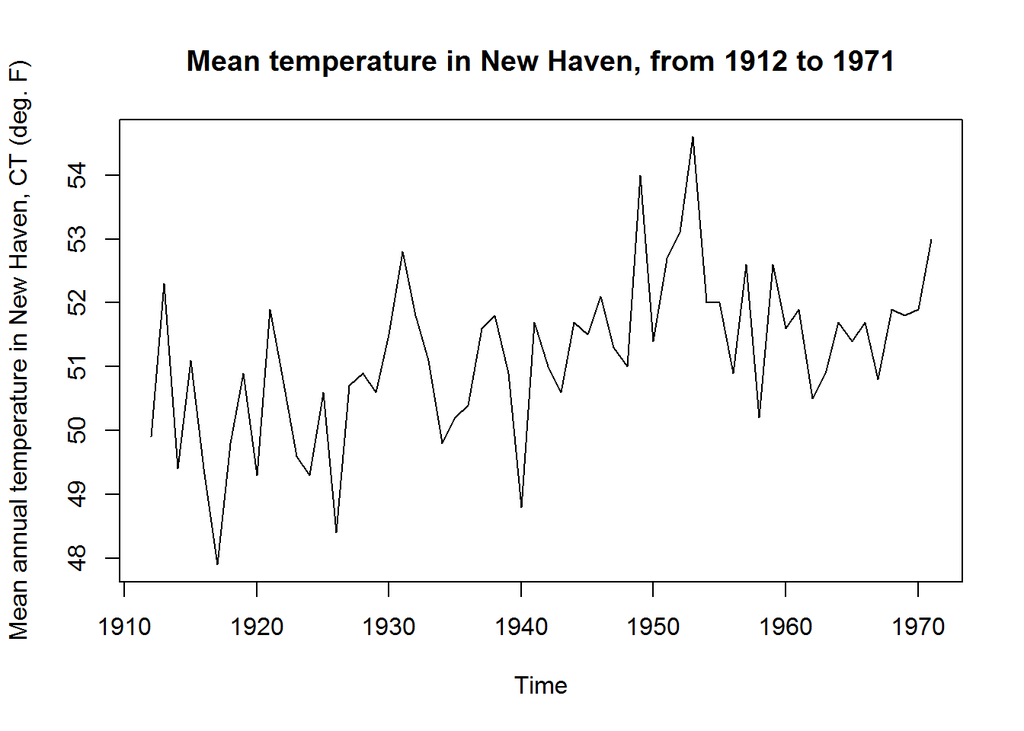

```r
data(nhtemp);require(stats); require(graphics);
plot(nhtemp, main = "Mean temperature in New Haven, from 1912 to 1971",ylab = "Mean annual temperature in New Haven, CT (deg. F)")
```